Faculty of Social Sciences  
Inaugural Lecture Series 2024/25

Estimating Ethnic Disparities in Sentencing:  
Methodological Challenges and a Path Forward

Jose Pina-Sánchez

Thanks Louise for such nice introduction, I am not good at taking complimnets so I am beyond embarrased right now.

And thanks Paul and Izzy for organising this series of Inaugural lectures, which give us the opportunity to come together and learn from the great research taking place in our faculty.

Ok, this is a talk about methods, so I apologise in advance. When Izzy approach me to see if I wanted to give one of these inaugural lectures she highlighted that I should avoid using technical jargon, and I tried, like for a few hours, but I found that I could not so I gave up, so you will have to bear with me.

The reason for that is because the main point I want to make is that research methods matters, how we should highlight their importance, invest in their teaching and development, and how without them we are in many ways fooling ourselves.

But to illustrate that underlying message I am going to focus on the topic of ethnic disparities in sentencing. A topic that is quite important both legally and politically, and consequently central to much of the research we undertake in the faculty, in particular the disparities/discrimination angle, while the sentencing part also makes it central to some of the research we do in Law and criminology. So I am hoping that it won’t be too boring.

# Background

OK, let’s get started.

## Sentencing

- The strongest expression of the coercive powers of the state
- Clear material consequences
- Equally important symbolic value

Why does sentencing matter?

Well, for one, it is the strongest expression of the coercive powers of the state.

It can both save and destroy lives.

However, sentencing is also a public ceremony, through which the state communicates what it understands as wrongdoing and its consequences.

Sentencing is the delivery of justice by the state, often represented by Lady Justice, who is blind to convey the essential principle that we are all equal under the law. It is therefore essential that both for material but also symbolic reasons sentencing is not discriminatory.

## Disparities in England & Wales

- The Lammy Review (2017)

  – 240% higher odds of custody for minority drug offenders

  – side note: 2.4 odds ratio $=$ 140% higher odds
- Is this evidence of discrimination?
- No definitive answer

  – we have not done our job

The question, of course, is, is it really blind?

David Lammy, the current foreign secretary - a politician I really like by the way, as he is one of the few that really stood up against the Brexit rethoric in all these years - he was commissioned by David Cameron to author an independent review of ethnic disparities in the criminal justice system in England & Wales.

In the chapter on sentencing, the Lammy Review highlighted a data point that was quite revealing. 240% higher odds of custody for ethnic minority offenders who are sentenced for a drug offence, compared to their white counterparts.

This data point was derived from an older MoJ report. They used a representative sample of offenders sentenced in the Crown Court, and controlled for guilty plea, previous convictions, and age and sex of the offender.

Side note: the true figure is 140%. There you go, even an independent review commissioned by the UK government can also make massive gaffes, which btw continue to be propagated and uncorrected. I will get back to that later.

Is this evidence of discrimination? What do you think? Raise your hands if you think that is the case. Ok, anyone who might consider that this is insufficient evidence to claim there is discrimination in sentencing in England and Wales? And why would you think that?

That is the position adopted by the Sentencing Council, the Ministry of Justice, and most of researchers working on this area, including myself back in the day, most of us caveat our findings indicating that the presence of such disparities does not equate judicial discrimination.

That is because this is a harder question that it might appear at first sight. When we make these kind of blunt comparisons with real world (non-experimental) data, it is likely that they are biased. It is possible that the two groups are not entirely comparable, and that the observed disparities are legitimate. For example, we know that black offenders are less likely to plead guilty, and do so at a later stage, regarding drug offenders specifically, it also seems to be the case that the quantities and types of drugs with which white offenders are charged are lower and less dangerous.

No definitive answer. How to interpret this evidence seems a personal choice. I am going to argue that this is suboptimal position to be in, and the result that we have not looked into the questions in enough detail. There are questions for which the data is not good enough to have a clear answer, but there are also instances where going in more depth, using better methods, and just plainly being more throrough, we can come up with definitive answers. And I am going to try to make the case that this is one of them.

## Real-world implications

- A. There is discrimination but we fail to acknowledge it

  – we perpetuate a terrible injustice
- B. There is no discrimination but we claim there is

  – we undermine trust in the criminal justice system

  – alienate minority groups

  – waste efforts by focusing on the wrong crisis

What are the implications of this impasse? We could be facing one of two options, neither is good, so we are in a suboptimal position.

We undermine trust in the criminal justice system, which incidentally leads to stronger disparities.

Alienate minority groups. Simply perceiving to be the subject of discrimination has political, social and even health related consequences.

Focus on the wrong crisis. Tomorrow is the last day to submit evidence to the second independent sentencing review of the month.

# Methodological challenges

Ok, so now you have the background. Let’s get into the main stuff. I am going to proceed to review some of the methodological problems that could bias our findings.

Then suggest some possible solutions.

Then put forward my own conclusion on this matter.

## Confounding bias

- Practically impossible to make ‘like-with-like’ comparisons

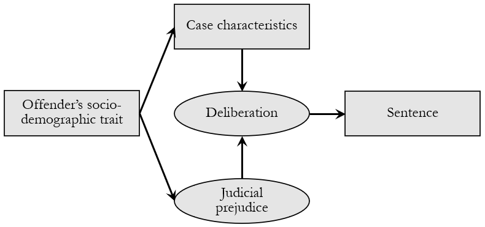

We can see this problem using causal diagrams. In this case it is a bit of an overkill but you will see how these diagrams can become quite useful in a minute. Disparities might be due to relevant case characteristics rather than judicial prejudice.

This is the problem that I set out to explore in more detail when I started planning my project, but soon enough I noticed many other methodological challenges that might be making our findings even more uncertain.

## Post-treatment bias

- We might be inadvertedly controlling away judicial prejudice

  – e.g. offender’s remorse and rehabilitation potential

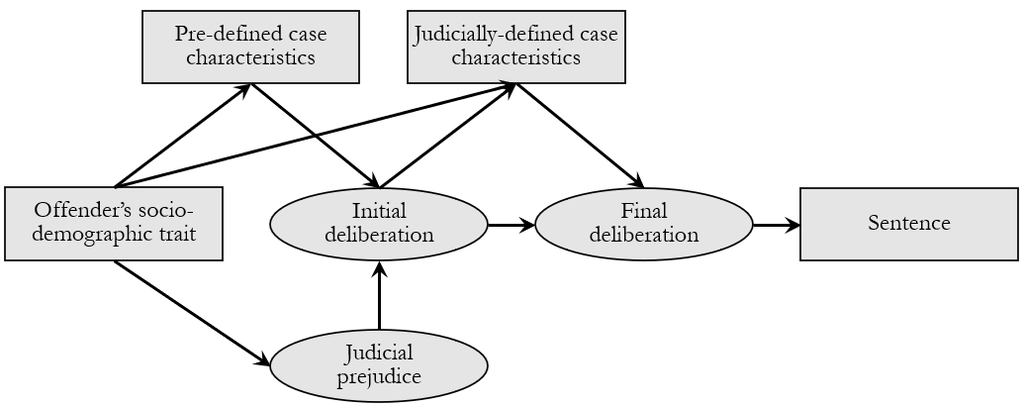

I have been such a stickler repeating that we have to control for all case characteristics if we want to come up with ‘like-with-like’ comparisons. I realised I was wrong. With the help of Peter and Melissa, I realised that we might be controlling for some factors that are discretionally decided by the judge.

In paper published last year in the BJC, we found that it is particularly the more subjective factors, such as remorse, good character, etc., the ones that are more likely to be present amongst white offenders. So judicial prejudice does not really need to appear the moment the final is imposed for judicial discrimination to be present.

In that case, judicial prejudice becomes unidentifiable, it is just not possible to provide a specific answer, there is not one.

## Misclassification & missing data

- White offenders are not a homogeneous group
- Different patterns of missing data depending on who identifies offender’s ethnicity

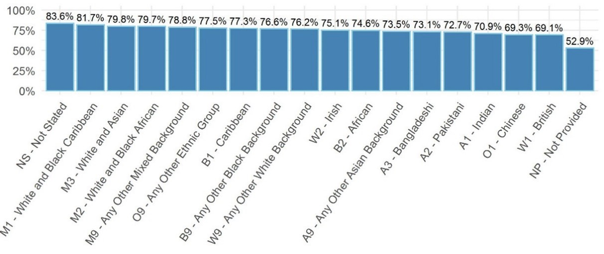

## Framing bias

- Research culture matters just as much

  – ‘race studies’ show twice stronger disparities than other sentencing studies
- Systematic cherry picking

  – every new study highlights the “240% higher odds”

Research culture matters just as much as research methods. Misaligned professional incentives lead to bias. In a recent meta-analysis we have recently carried out, we find that sentencing studies that refer to themselves as race or ethnicity papers show 2 times stronger disparities than other sentencing studies where race is simply used as a control, not the key variable of interest.

Few studies refer to the absence of disparities found for sex and violence offenders.

# So, can we tell whether there is discrimination?

## We can estimate some uncertainty

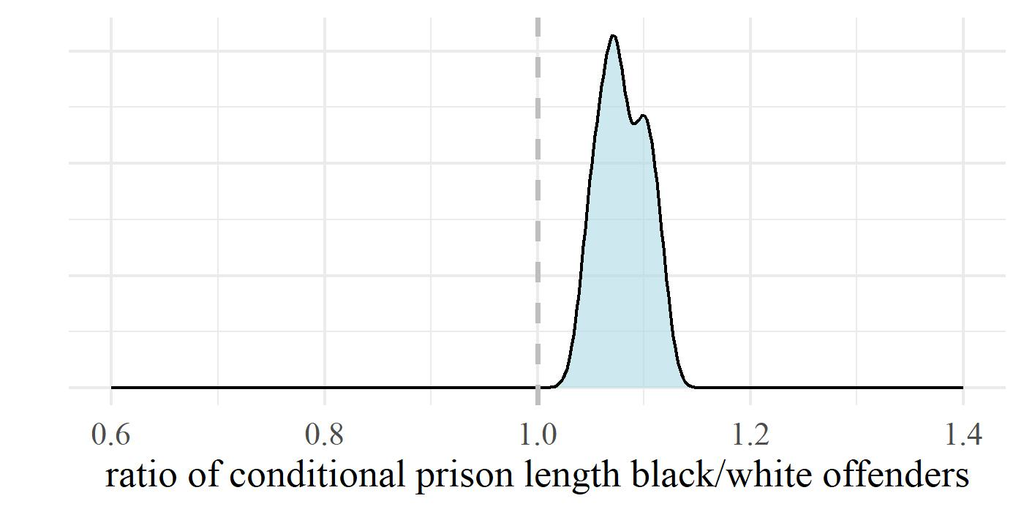

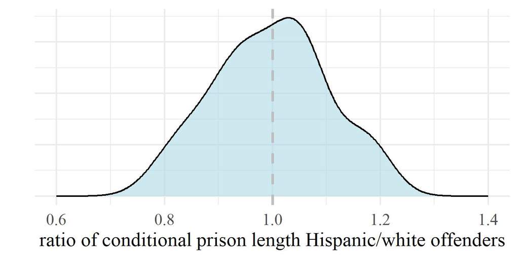

In this paper I have written with Melissa and Peter w say, right, there is not perfect combination of controls, therefore there is not a perfect answer, but we can sill estimate the model uncertainty that arises when we control or fail to control for case characteristics that are subjectively defined by the judge. So, let’s run all possible combinations and uncover how much uncertainty there is as a result of that problem.

## We can evaluate bias qualitatively

- Missing legal factors isn’t a sufficient condition for statistical bias
- Sentencing Council (2021) conditioned on all factors listed in their guidelines

  – still found significant disparities (40% higher odds)
- No missing legal factor is realistically strong enough to render those disparities non-significant
- These missing factors also need to be associated with ethnicity.
- To render results inconclusive, the bias should be stronger than the reported disparities
- The Sentencing Council replicated the Lammy Review.
- conditioned on all factors listed in the sentencing guidelines, but missed others like dangerousness or caught red-handed
- We demonstrated that no missing legal factor could be strong enough to render the observed disparities non-significant.

-For example, in one of the four scenarios identified, the unobserved legal factors would need to: i) increase the probability of custody by at least 10%; ii) be present in at least 70% of the reference group (white offenders); and iii) be at least 20% more prevalent in the treatment group (i.e., present in at least 84% of Black offenders).

## Anticipate the direction of the bias

- Disparities could be understimated

  – the Council controlled for mitigating factors we suspect are ‘racially-constructed’

  – did not differentiate between groups of whites
- We do not find evidence of bias in missing data

## My conclusion

- We can provide a definitive answer

  – there is sentencing discrimination in England & Wales
- However, the problem is not as widespread as commonly expressed

  – we only see it in 1 out of 9 offence groups, drug offences
- The literature is plagued with wrong results (misinformation)

  – we need to change radically how we do research

-By wrong I mean that they are confidently giving us a finding that is objectively incorrect, or that they are unnecessarily caveating their findings so much that anyone can make of the results what they want. -And of course I am as guilty as anyone else or more. - I have changed my mind multiple times as I kept delving into this topic.

# How Do We Move Forward?

## Invest in research methods

- Every researcher should be able to identify research assumptions

  – and assess how their breach could lead to bias
- Empirical researchers should be able to estimate those biases

  – and reflect them in the uncertainty of their findings

-This involves being explicit about the assumptions upon which our findings rest. Embrace the uncertainty stemming from them and integrate it in our findings. Trade precision for accuracy, so we can avoid bias. Put differently, stop being so confident about our findings. We can do this with methods like specification curves and sensitivity analysis.

- I do not think I am there yet
- 15 years since I started my PhD

## A Messy Trajectory

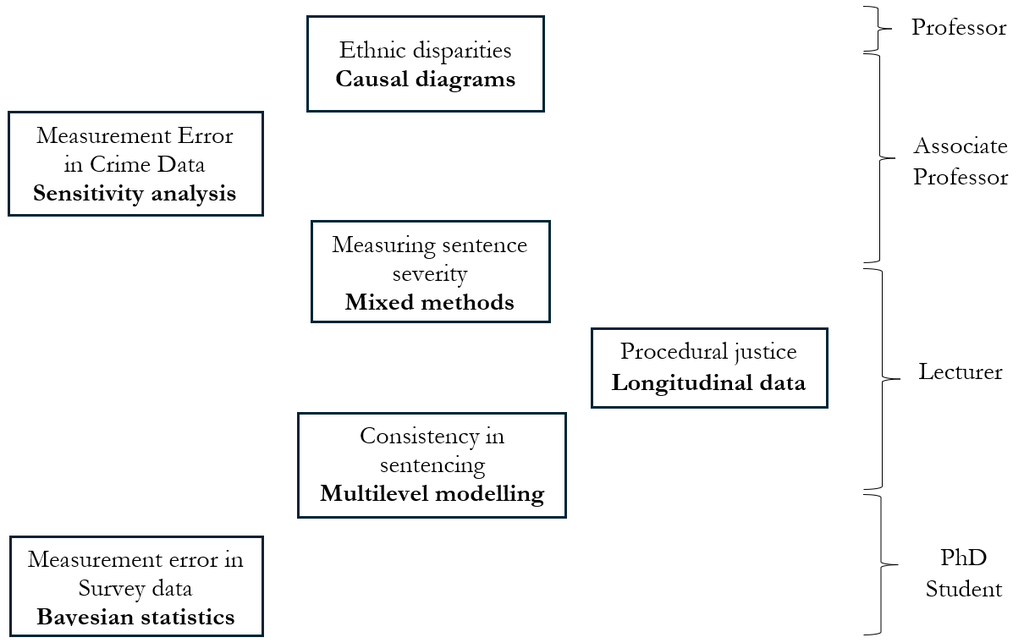

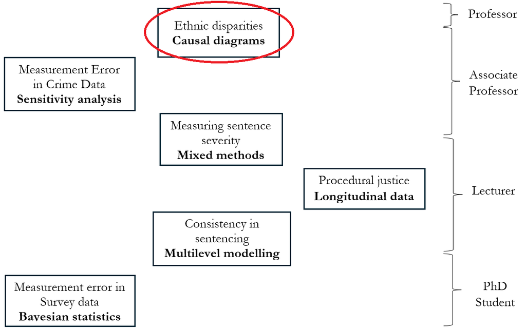

- Around here I started questioning my research. Around here I hit an existential crisis thinking all is pointless. It is only lately I am thinking that there are ways we can change this.

## Change of research culture

- Slow research

  – quality over quantity
- Embrace uncertainty

  – acknowledge our assumptions

  – trade precision for accuracy

  – avoid overhyping
- Open research

  – registered reports

  – replications

# If we try hard enough, and do not fool ourselves along the way, we can answer pretty hard questions